# SDG Data Analysis Tutorial

Now we only have to invert the indicators that should decline as we get closer to SDGs. To do this, we merge the summary with the wide data frame and then multiply the “year” columns by the “direction” value. When done, make sure to compare to the previous version to see if the values were changed.

```r
sdg.wide<-merge(sdg.wide, sdg3.sum, by="Indicator")
sdg.wide[,2:22]<-sdg.wide[,2:22]*sdg.wide$direction#this command tells R to take columns 2 to 22 and multiply the content by the "direction" column
head(sdg.wide)
```

```
##   Indicator       2000       2001       2002       2003       2004       2005
## 1    10.4.1         NA         NA         NA         NA -0.1458410 -0.1458416
## 2    10.b.1 -0.1456129 -0.1456242 -0.1456442 -0.1455588 -0.1455034 -0.1454891
## 3    15.4.1 -0.1458293 -0.1458293 -0.1458292 -0.1458292 -0.1458292 -0.1458292
## 4    15.5.1 -0.1458533 -0.1458533 -0.1458533 -0.1458533 -0.1458533 -0.1458533
## 5    15.a.1         NA         NA  0.1458527  0.1458529  0.1458509  0.1458525
## 6    15.b.1         NA         NA -0.1458527 -0.1458529 -0.1458509 -0.1458525
##         2006       2007       2008       2009       2010       2011       2012
## 1 -0.1458415 -0.1458417 -0.1458422 -0.1458420 -0.1458421 -0.1458422 -0.1458417
## 2 -0.1453891 -0.1453221 -0.1453050 -0.1452694 -0.1453154 -0.1453759 -0.1453373
## 3 -0.1458292 -0.1458292 -0.1458292 -0.1458292 -0.1458292 -0.1458292 -0.1458292
## 4 -0.1458533 -0.1458533 -0.1458533 -0.1458533 -0.1458533 -0.1458533 -0.1458533
## 5  0.1458523  0.1458433  0.1458463  0.1458439  0.1458232  0.1458406  0.1458447
## 6 -0.1458523 -0.1458433 -0.1458463 -0.1458439 -0.1458232 -0.1458406 -0.1458447
##         2013       2014       2015       2016       2017       2018       2019
```

[output cut: 27 more lines]

Now, we finally have what we need. Let’s extract the matrix of the standardized values to do the cross-correlation analysis.

```r
sdg.mat<-as.matrix(sdg.wide[,2:22])
str(sdg.mat) #looks like we almost have the right format, we only need to transpose the matrix
```

```
##  num [1:24, 1:21] NA -0.146 -0.146 -0.146 NA ...
##  - attr(*, "dimnames")=List of 2
##   ..$ : NULL
##   ..$ : chr [1:21] "2000" "2001" "2002" "2003" ...
```

```r
sdg.mat<-t(sdg.mat)
```

Time to use the `cor2()` command to run the correlations among all rows in this matrix. The result is a matrix of Pearson correlation coefficients.

```r
sdg.correlations<-cor2(sdg.mat, y=NULL, circ=F)
```

Now we have a matrix in which each row and column is an Indicator and each cell is the correlation among each pairing. Let’s put the Indicator names back in. Also, for simplification, we will round the values to two places behind the comma.And then we save a copy as a file and take a look

```r
rownames(sdg.correlations)<-sdg.wide$Indicator
colnames(sdg.correlations)<-sdg.wide$Indicator
sdg.correlations<-round(sdg.correlations,2)
write.csv(sdg.correlations, "correlation_matrix_Uganda.csv")
sdg.correlations
```

```
##        10.4.1 10.b.1 15.4.1 15.5.1 15.a.1 15.b.1 17.1.2 17.3.2 17.4.1 17.8.1
## 10.4.1   1.00  -0.53     NA   0.71   0.62  -0.62  -0.77  -0.11  -0.72   0.72
## 10.b.1  -0.53   1.00   0.43  -0.79  -0.65   0.65   0.70  -0.54   0.69  -0.73
## 15.4.1     NA   0.43   1.00  -0.51     NA     NA   0.48  -0.22   0.37  -0.40
## 15.5.1   0.71  -0.79  -0.51   1.00   0.74  -0.74  -0.84   0.37  -0.71   0.98
## 15.a.1   0.62  -0.65     NA   0.74   1.00  -1.00  -0.52   0.44  -0.68   0.73
## 15.b.1  -0.62   0.65     NA  -0.74  -1.00   1.00   0.52  -0.44   0.68  -0.73
## 17.1.2  -0.77   0.70   0.48  -0.84  -0.52   0.52   1.00  -0.55   0.77  -0.78
## 17.3.2  -0.11  -0.54  -0.22   0.37   0.44  -0.44  -0.55   1.00  -0.33   0.32
## 17.4.1  -0.72   0.69   0.37  -0.71  -0.68   0.68   0.77  -0.33   1.00  -0.77
## 17.8.1   0.72  -0.73  -0.40   0.98   0.73  -0.73  -0.78   0.32  -0.77   1.00
## 17.9.1   0.69  -0.22  -0.46   0.41   0.19  -0.19  -0.02  -0.51  -0.24   0.45
## 2.a.2   -0.46   0.58   0.05  -0.74  -0.55   0.55   0.77  -0.47   0.63  -0.73
## 3.1.1   -0.77   0.79   0.62  -0.99  -0.76   0.76   0.86  -0.43   0.84  -0.94
## 3.3.2   -0.83   0.77   0.71  -0.93  -0.74   0.74   0.88  -0.45   0.81  -0.86
## 3.3.5   -0.39   0.00     NA  -0.71   0.33  -0.33   0.45   0.53  -0.82  -0.65
## 5.5.1   -0.56   0.69   0.43  -0.95  -0.60   0.60   0.72  -0.24   0.53  -0.92
## 6.a.1   -0.42   0.48   0.39  -0.61  -0.35   0.35   0.65  -0.36   0.64  -0.57
## 7.2.1    0.67  -0.75  -0.41   0.97   0.69  -0.69  -0.81   0.41  -0.72   0.96
## 7.3.1    0.82  -0.76  -0.59   0.95   0.71  -0.71  -0.93   0.48  -0.89   0.91
## 7.a.1   -0.23   0.21   0.15  -0.36  -0.66   0.66   0.31  -0.26   0.36  -0.32
## 8.1.1    0.08  -0.35  -0.07   0.41   0.38  -0.38  -0.28   0.23  -0.28   0.60
## 8.2.1    0.22  -0.24   0.16   0.42   0.62  -0.62  -0.23   0.34  -0.13   0.52
## 9.a.1   -0.73   0.46  -0.10  -0.47  -0.75   0.75   0.48  -0.23   0.79  -0.48
## 9.b.1      NA     NA     NA     NA     NA     NA     NA     NA     NA     NA
##        17.9.1 2.a.2 3.1.1 3.3.2 3.3.5 5.5.1 6.a.1 7.2.1 7.3.1 7.a.1 8.1.1 8.2.1
## 10.4.1   0.69 -0.46 -0.77 -0.83 -0.39 -0.56 -0.42  0.67  0.82 -0.23  0.08  0.22
## 10.b.1  -0.22  0.58  0.79  0.77  0.00  0.69  0.48 -0.75 -0.76  0.21 -0.35 -0.24
## 15.4.1  -0.46  0.05  0.62  0.71    NA  0.43  0.39 -0.41 -0.59  0.15 -0.07  0.16
## 15.5.1   0.41 -0.74 -0.99 -0.93 -0.71 -0.95 -0.61  0.97  0.95 -0.36  0.41  0.42
## 15.a.1   0.19 -0.55 -0.76 -0.74  0.33 -0.60 -0.35  0.69  0.71 -0.66  0.38  0.62
## 15.b.1  -0.19  0.55  0.76  0.74 -0.33  0.60  0.35 -0.69 -0.71  0.66 -0.38 -0.62
## 17.1.2  -0.02  0.77  0.86  0.88  0.45  0.72  0.65 -0.81 -0.93  0.31 -0.28 -0.23
## 17.3.2  -0.51 -0.47 -0.43 -0.45  0.53 -0.24 -0.36  0.41  0.48 -0.26  0.23  0.34
## 17.4.1  -0.24  0.63  0.84  0.81 -0.82  0.53  0.64 -0.72 -0.89  0.36 -0.28 -0.13
## 17.8.1   0.45 -0.73 -0.94 -0.86 -0.65 -0.92 -0.57  0.96  0.91 -0.32  0.60  0.52
## 17.9.1   1.00  0.06 -0.41 -0.35 -0.71 -0.49 -0.19  0.36  0.29 -0.03  0.16  0.04
## 2.a.2    0.06  1.00  0.69  0.62  0.20  0.76  0.56 -0.78 -0.67  0.49 -0.47 -0.52
## 3.1.1   -0.41  0.69  1.00  0.98  0.51  0.89  0.64 -0.93 -0.97  0.36 -0.46 -0.34
## 3.3.2   -0.35  0.62  0.98  1.00  0.46  0.80  0.66 -0.86 -0.97  0.34 -0.29 -0.24
```

[output cut: 20 more lines]

```
## 17.8.1 -0.48    NA
## 17.9.1 -0.05    NA
## 2.a.2   0.51    NA
## 3.1.1   0.48    NA
## 3.3.2   0.48    NA
## 3.3.5  -0.62    NA
## 5.5.1   0.35    NA
## 6.a.1   0.44    NA
## 7.2.1  -0.41    NA
## 7.3.1  -0.53    NA
## 7.a.1   0.40    NA
## 8.1.1   0.02    NA
## 8.2.1  -0.25    NA
## 9.a.1   1.00    NA
## 9.b.1     NA    NA
```

Now what? The first thing that becomes evident is that there are no results for the indicator “9.b.1”. Let’s look at the data for this indicator

```r
sdg.wide[sdg.wide$Indicator=="9.b.1",]
```

```
##    Indicator       2000       2001       2002       2003       2004       2005
## 24     9.b.1 -0.1458503 -0.1458503 -0.1458503 -0.1458503 -0.1458503 -0.1458503
##          2006       2007       2008       2009       2010       2011       2012
## 24 -0.1458503 -0.1458503 -0.1458503 -0.1458503 -0.1458503 -0.1458503 -0.1458503
##          2013       2014       2015       2016       2017 2018 2019 2020 Goal
## 24 -0.1458503 -0.1458503 -0.1458503 -0.1458503 -0.1458503   NA   NA   NA    9
##    Target
## 24    9.b
##                                                                   SeriesDescription
## 24 Proportion of medium and high-tech industry value added in total value added (%)
##    GeoAreaName TimePeriod Value   Units direction
## 24      Uganda       2000 11.07 PERCENT         1
```

```r
sdg.correlations<-sdg.correlations[-c(18,25),]  #first get rid of rows
sdg.correlations<-sdg.correlations[,-c(18,25)]  #now columns
```

Ok, almost there. We have a few more NA values left. For now, we just turn them into zeros, though you may want to investigate them further.

```r
sdg.correlations[is.na(sdg.correlations)]<-0
```

Now, let’s get an overview and make a plot for the results. (Note that each pair is represented twice in the matrix)

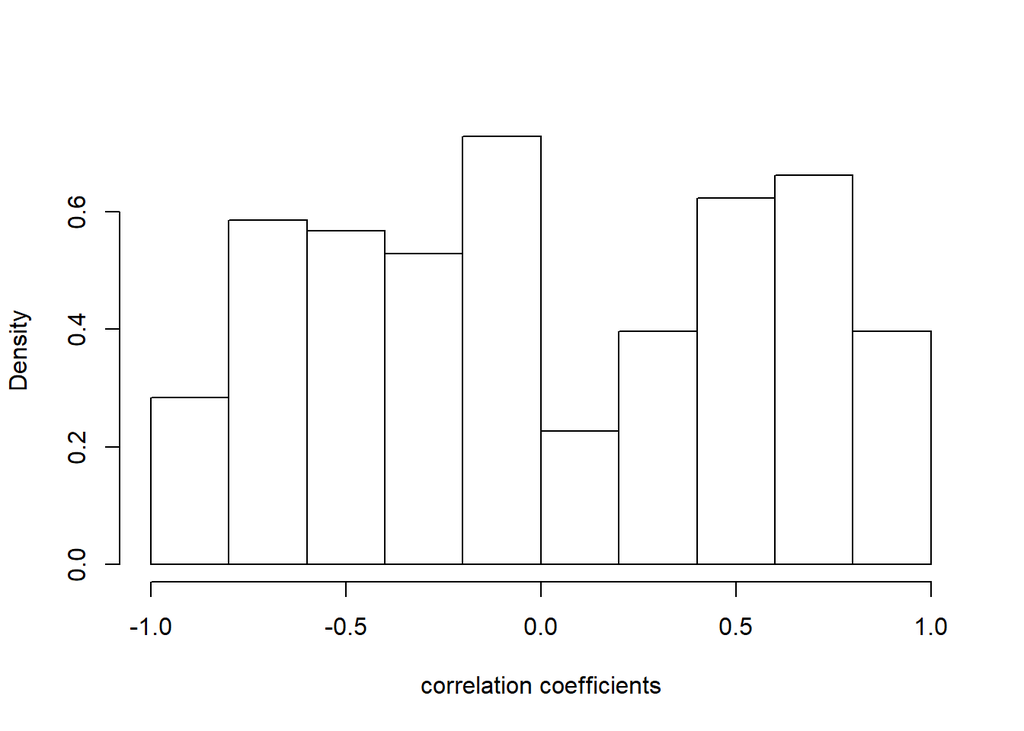

```r
hist(sdg.correlations, freq=F, xlab="correlation coefficients", main="")
```

Now, let’s create a heatmap that illustrates the correlations. For this, we use the package “corrplot” [use `install.package(“corrplot”)] First, we can create a heat map with clustering (so the closely related parameters are next to each other)

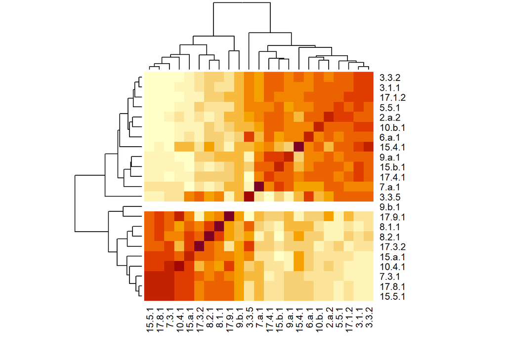

```r
library(corrplot)
heatmap(sdg.correlations, Rowv=NULL, Colv=NULL)
```

Or we can do the same without clustering, so that the sequence of indicators follows the matrix layout

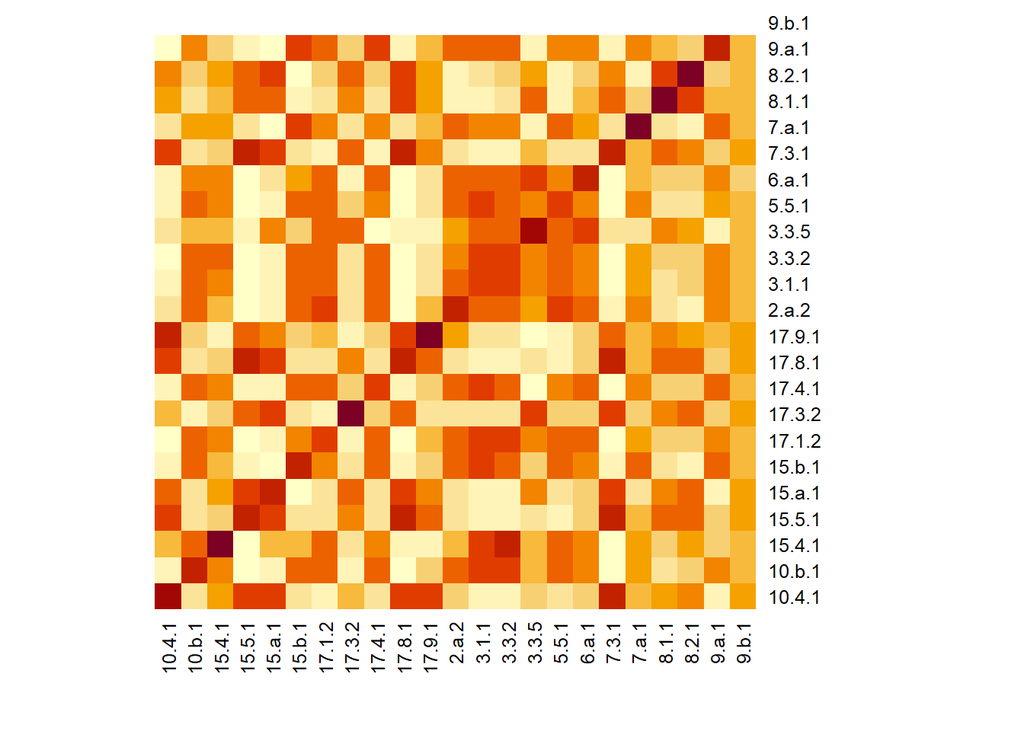

```r
heatmap(sdg.correlations, Rowv=NA, Colv=NA)
```

Finally, we can plot a correlogram, which shows the correlation matrix in a different format

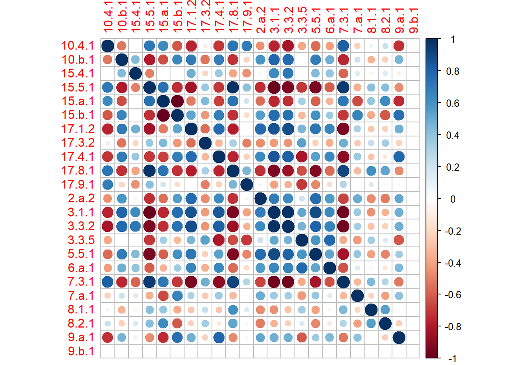

```r
corrplot(sdg.correlations)
```

To save the figure, you can click “Export” above the figure and store it to your project folder